# R Notebook

# LOAD DATASET

```r
hsb2_t <- read.csv("hsb2.csv")
```

# The datasets’ collection:

https://vincentarelbundock.github.io/Rdatasets/articles/data.html

# Der Datensatz für Pearson, t-Test (unabh.) und ANOVA:

https://vincentarelbundock.github.io/Rdatasets/csv/openintro/hsb2.csv https://vincentarelbundock.github.io/Rdatasets/doc/openintro/hsb2.html siehe auch Anhang für alle Variabeln

# Beschreibung

200 Beobachtungen wurden nach einem Zufallsprinzip im Rahmen einer Umfrage des US-Nationalen Zentrums für Bildungsstatistiken (National Center of Education Statistics) unter Oberstufenschülern (High School and Beyond) durchgeführt.

# Daten:

200 Beobachtungen 11 Variablen

# T-Test für unabhängige Stichproben

Es wird ein Signifikanzniveau von alpha = 0.05 angenommen.

## Was soll untersucht werden?:

Besteht ein Unterschied zwischen dem Schreibscore von Probanden aus öffentlichen Schulen und privaten Schulen?

## ANALYSE GLIEDERUNG:

0 Grundlegendes Konzept 1 Hypothese 2 Voraussetzungen 3 Deskriptive Statistik 4 Graphische Darstellung 5 Shapiro-Wilk 6 Test auf Varianz-Homogenität (Levene-Test) 7 T-Test mit Welch-Korrektur 8 Berechnung der Effektstärke 9 Aussage 10 Anhang

## Grundlegendes Konzept

Der t-Test für unabhängige Stichproben testet, ob die Mittelwerte zweier unabhängiger Stichproben verschieden sind.

Die Fragestellung des t-Tests für unabhängige Stichproben wird oft so verkürzt: “Unterscheiden sich die Mittelwerte zweier unabhängiger Stichproben?”

# Hypothese

H1: Es gibt einen Unterschied zwischen dem durschnittlichen Schreibscore (write) von Probanden, die eine öffentliche oder private Schule (schtyp) besucht haben. M1≠M2

H0: Es gibt keinen Unterschied zwischen dem durschnittlichen Schreibscore (write) von Probanden, die eine öffentliche oder private Schule (schtyp) besucht haben. M1=M2

# Voraussetzungen

Die abhängige Variable ist min. intervallskaliert -> Ja, Schreibscore ist metrisch und intervallskalliert. Es liegt eine unabhängige Variable vor, mittels der die beiden zu vergleichenden Gruppen gebildet werden können. -> Ja, öffentliche und private Schule (nominal skaliert). Das untersuchte Merkmal ist in den Grundgesamtheiten der beiden Gruppen normalverteilt -> Es liegt keine Normalverteilung in einer der Gruppen vor (siehe Histogramm und Shapiro-Wilk) Homogenität der Varianzen: Es liegt Heterogenität vor (siehe Levene-Test), entsprechend muss eine Korrektur (Welch-Korrektur) vorgenommen werden. Die einzelnen Messwerte sind voneinander unabhängig (das Verhalten einer Versuchsperson hat keinen Einfluss auf das Verhalten einer anderen) -> ist gegeben.

# Deskripitve Statistik

```r
library(dplyr)
hsb2_t %>%
group_by(schtyp) %>%
  summarize(Anzahl = n(), Mittelwert = mean(write), Median = median(write), Standardabweichung = sd(write)) %>%
  mutate_if(is.numeric, round, 2)
```

| schtyp | Anzahl | Mittelwert | Median | Standardabweichung |
| --- | --- | --- | --- | --- |
| private | 32 | 55.53 | 57 | 7.18 |
| public | 168 | 52.25 | 54 | 9.79 |

Es gibt keine fehlenden Werte.

Problematisch ist das hier die Gruppen unterschiedlich groß sind. Der T-Test wird ungenauer, wenn die Gruppengrößen (stark) unterschiedlich sind. Das muss bei der Interpretation beachtet werden.

Es zeigt sich für diese Fragestellung ein geringer Mittelwertsunterschied. Der Schreib-Score bei Privatschülern ist höher (M = 55.53 SD = 7.18, n = 32) als bei Schülern der öffentlichen Schulen (M = 52.25 SD = 9.79, n = 168).

## Graphische Darstellung

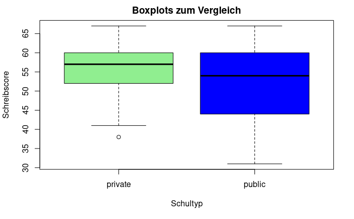

```r
boxplot(hsb2_t$write ~ hsb2_t$schtyp, main = "Boxplots zum Vergleich", ylab = "Schreibscore", xlab= "Schultyp" , col = c("lightgreen", "blue"))
```

Im Boxplot ist ebenfalls zu sehen, dass die Mittelwerte doch recht nah beieinander liegen. Bei der Privatschule gibt es einen Ausreißer nach unten. Aufgrund der wenigen Ausreißer wird diese beibehalten und die Daten nicht bearbeitet.

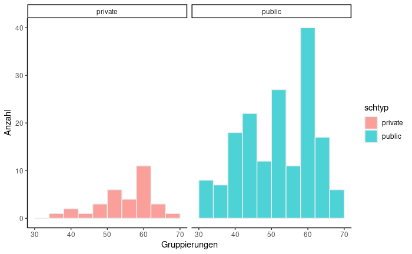

```r
library(dplyr)
library(ggplot2)

  hsb2_t %>%
  group_by(schtyp) %>%
  ggplot(aes(write)) +
    geom_histogram( binwidth=4, aes(fill=schtyp), color="#e9ecef", alpha=0.7 ) +
   facet_wrap(~schtyp)+
    theme_classic()+
    labs(x="Gruppierungen", y="Anzahl")
```

Man könnte gerade so von einer Normalverteilung ausgehen.

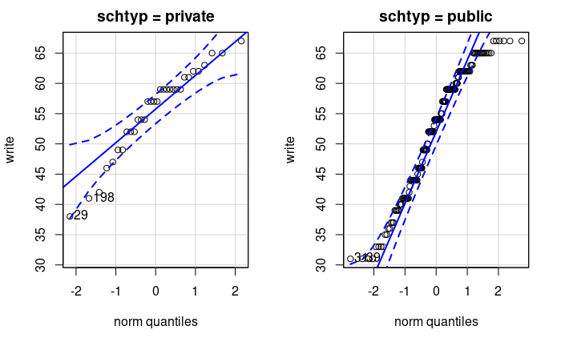

```r
library(car)

qqPlot(write ~ schtyp, data=hsb2_t,
       layout=c(1, 2))
```

Im Qq-Plot kann man sehen, dass es möglicherweise eine Verletzung der Normalverteilungsvoraussetzung geben könnte. Vorallem in der Gruppe “public”.

```r
dfpub <- hsb2_t %>% filter(hsb2_t$schtyp == "public")
```

```r
dfpriv <- hsb2_t %>% filter(hsb2_t$schtyp == "private")
```